# Final Project Wengran Xiao

2022-12-07

## My topic

The purpose of this project is to find the relationship between the number of infant death and the GDP per capita of each country. Theoretically, a country with low GDP per capital has less health resources, low-quality food, heavier workload and low medical techniques for the population, which will lead to more infant death.

## Initialize two datasets

There are two original datasets used for the project. The file data1 has a series of life expectancy data of different years of all the countries in the world. The file data2 has the GDP data of different years of countries.

```r
library(dplyr)
```

```r
library(ggplot2)
library(skimr)
library(moderndive)
library(infer)
library(tidyr)
```

```r
data1<-read.csv("/Users/wengranxiao/Desktop/SI544/final_project/Life_Expectancy_Data.csv")

data2<- read.csv("/Users/wengranxiao/Desktop/SI544/final_project/GDP.csv")
```

## Wrangling the data

Only infant death of the Year 2014 and 2015 is needed and the GDP of 2015 is needed, so the two original charts should be wrangled and combined together.

```r
data1 <-data1 %>%
  filter(Year=="2015"|Year=="2014")%>%
  select(Country,infant.deaths,Year)
```

```r
data2 <- data2 %>%
  select(Country,X2015) %>%
  rename(GDP=X2015)
```

```r
finaldata <- data1 %>%
  inner_join(data2,by="Country")
```

## Descriptive statistics

Below are some descriptive statistics of the finaldata to help better understand the dataset.

```r
# Mean and median
mean_death <-mean(finaldata$infant.deaths)
mean_death
```

```
## [1] 24.58333
```

```r
median_death <-median(finaldata$infant.deaths)
median_death
```

```
## [1] 2
```

```r
# 25th and 75th percentile
pct_25 <-quantile(finaldata$infant.deaths,0.25)
pct_25
```

```
## 25%
##   0
```

```r
pct_75 <-quantile(finaldata$infant.deaths,0.75)
pct_75
```

```
##   75%
## 16.25
```

```r
# Range of infant death
max(finaldata$infant.deaths)-min(finaldata$infant.deaths)
```

```
## [1] 957
```

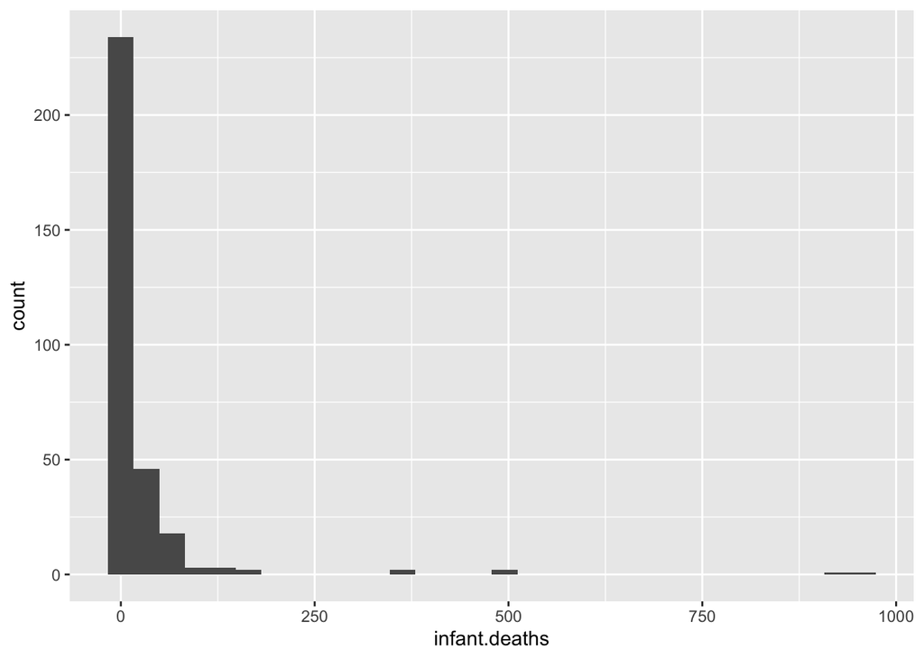

```r
# Draw a histogram to visualize the distribution of infant death
# It shows that the majority of the infant death locates in zero.

ggplot(finaldata, mapping=aes(x=infant.deaths))+
  geom_histogram()
```

## Fit linear model

To better understand and visualize the relationship between infant death and GDP of a country, firstly I draw a scatterplot and draw a linear. It seems when GDP increases, the death decreases.

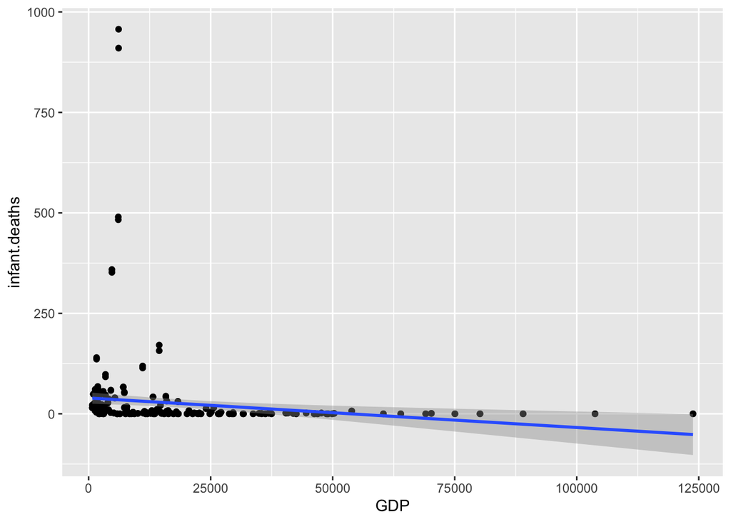

```r
ggplot(finaldata, aes(y = infant.deaths, x = GDP))+
  geom_point()+
  geom_smooth(method="lm")
```

## Interpret the linear model

Then I get a regression table to interpret the linear model. As shown in the regression table, “infant.death=-0.001*GDP+39.439”. This means when GDP increases by 1, the infant death will decrease by 0.001.

```r
reg_model <- lm(infant.deaths ~ GDP, data=finaldata)
get_regression_table(reg_model)
```

```
## # A tibble: 2 × 7
##   term      estimate std_error statistic p_value lower_ci upper_ci
##   <chr>        <dbl>     <dbl>     <dbl>   <dbl>    <dbl>    <dbl>
## 1 intercept   39.4        7.13      5.53   0       25.4       53.5
## 2 GDP         -0.001      0        -3.00   0.003   -0.001      0
```

## See the goodness of the linear model by r2

To test the effectiveness of the linear model, I then calculate the r-square. The r2 is 0.029, which is a very small number, so this is not a good linear model.

```r
get_regression_summaries(reg_model)
```

```
## # A tibble: 1 × 9
##   r_squared adj_r_squared   mse  rmse sigma statistic p_value    df  nobs
##       <dbl>         <dbl> <dbl> <dbl> <dbl>     <dbl>   <dbl> <dbl> <dbl>
## 1     0.029         0.026 8133.  90.2  90.5      9.02   0.003     1   302
```

## Conclusion

We can say that infant death and the GDP per capita of a country has certain relationship, but it cannot be perfectly interpreted by linear model.